Author: Nicolas Legrand nicolas.legrand@cfin.au.dk

# Heart Rate Discrimination task - Summary results

This notebook introduces basic analysis steps, plots and quality check for the Heart Rate Discrimination task. The current version use data from a young and healthy participant tested with the default task parameters implemented in the launcher.py file (80 trials per condition, 30 using a 1-Up/1-Down staircase and 50 using the Psi method.

The target directory is defined by the `path` variable and should include the following files: `final.txt` (the behavioural data), `Intero_posterior.npy` and `Extero_posterior.npy` (the posterior estimates) and `signal.txt` (the PPG signal time series during the interoception trials).

**Import data**

# Response time

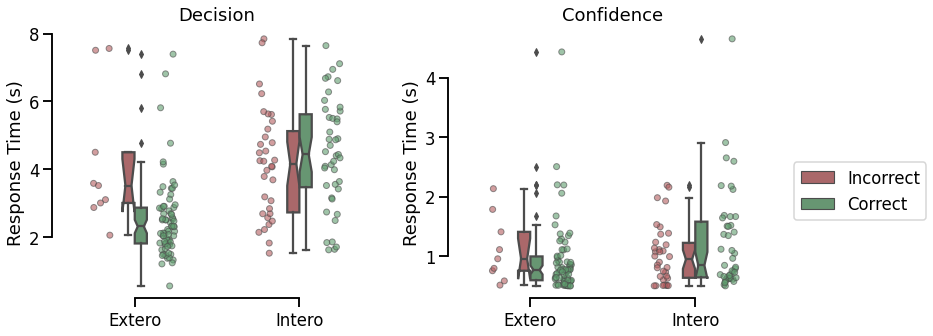

# Metacognition

SDT estimate for decision 1 perforamces (d' and criterion)

```
Condition: Intero - d-prime: 0.8530861406896058 - criterion: -0.3381666034415842
Condition: Extero - d-prime: 2.8229636935929427 - criterion: 0.503023978259086
```

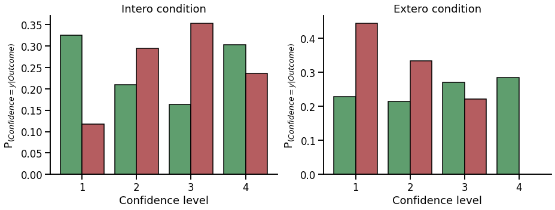

# Psychophysics

Distribution of the intensities values.

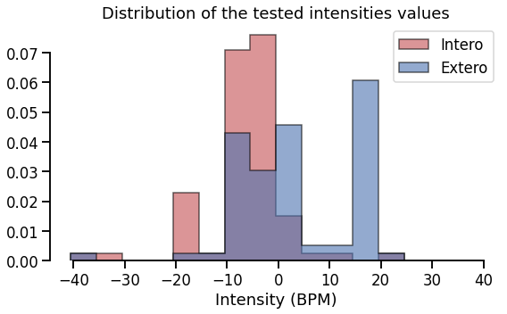

## Staircases

### Psi

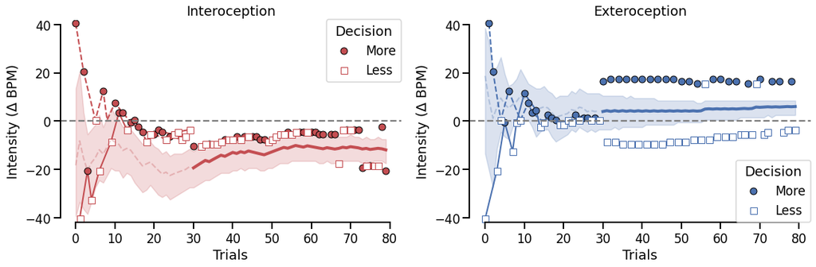

This figure represents the evolution of threshold estimate across trials for the Interoception and Exteroception condition. Shaded areas represent the 95% confidence interval of the threshold estimate by Psi. For each condition, the first 30 trials (connected with dashed lines) were allocated to an Up/Down method (2 interleaved staircases starting a -40.5 or 40 respectively). The intensities and responses were included in the Psi staircase to maximize the amount of information included. The remaining 50 trials were monitored by the Psi staircase only. This dual estimation was implemented to estimate the reliability of the estimation of threshold using an up/down procedure, as compared to a longer psi procedure.

# Psychometric function

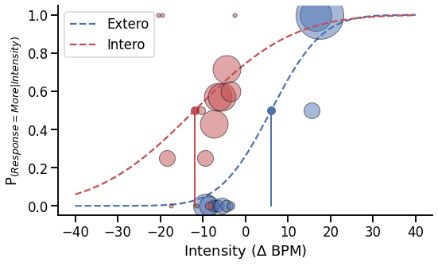

Psychometric functions fitted using the estimated threshold and slope from the final trial on each condition. The size of the circles reflects the proportion of responses for each intensity level.

# Pulse oximeter

## Visualization of PPG signal

This interactive graph shows the PPG signal recorded at each interoceptive trial. Blue and red time series represent different trials of 6 seconds each. In each trial, the 5 last seconds were used to estimate the average heart rate of the participant, the first second was included to help peak detection algorithm initialization.

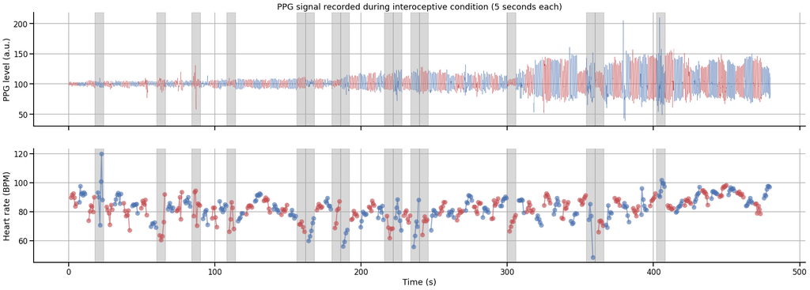

## Heart rate - Summary statistics

This figure show the evolution of the average and standard deviation of the instantaneous heart rate across time. An instantaneous frequnecy was derived between each peak detected in the PPG signal (also known as pulse-to-pulse intervals, or pseudo RR intervals). Rapid increase or decrease of the heart rate frequency can lead to larger standard deviation, and less accurate estimation of the average heart rate.

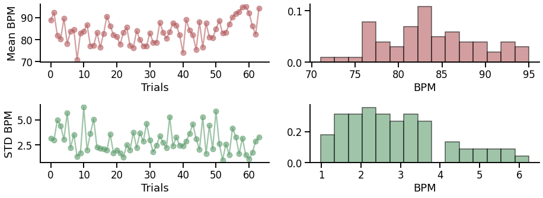

# Save dataframe

```
16 Interoception trials and 0 exteroception trials were dropped after trial rejection based on heart rate outliers.
```